# Monthly Sales Growth

Yen Low

06/11/2015

### Setup

Set paths and load dependencies

```
## [1] "/mnt/hgfs/projects/insight/models/timeseries"
```

### Load data

Get monthly sales

```
## [1] TRUE
```

Check number of stores (1487)

```r
#1487 stores
storeIDs=unique(totRev$customer_identifier)
length(storeIDs)
```

```
## [1] 1487
```

### Data Maniputation

```
##                    yr_month
## customer_identifier   201312   201401   201402   201403   201404   201405
##              000026  7308.46  7471.27  7058.72  7149.21  6450.22  7417.77
##              000417 54132.15 55989.89 50611.46 54746.30 66808.97 60093.12
##              001172 17653.26 12638.28 17118.09 15477.03 14744.88 20925.30
##                    yr_month
## customer_identifier   201406   201407   201408   201409   201410   201411
##              000026  6235.87  8697.47  7490.87  7942.73  5931.68  6696.31
##              000417 55707.91 54732.56 51053.87 64001.18 59228.98 57580.10
##              001172 15167.16 14767.59 22722.50 15483.37 20256.76 19729.66
##                    yr_month
## customer_identifier   201412   201501   201502   201503   201504   201505
##              000026 11036.47 10046.40  8226.74 10975.11  5981.79  8306.64
##              000417 72880.73 61522.36 46586.51 78327.21 60746.32 66894.11
##              001172 17699.07 19327.69 27242.59 21482.12 21587.88 31537.01
```

View time series

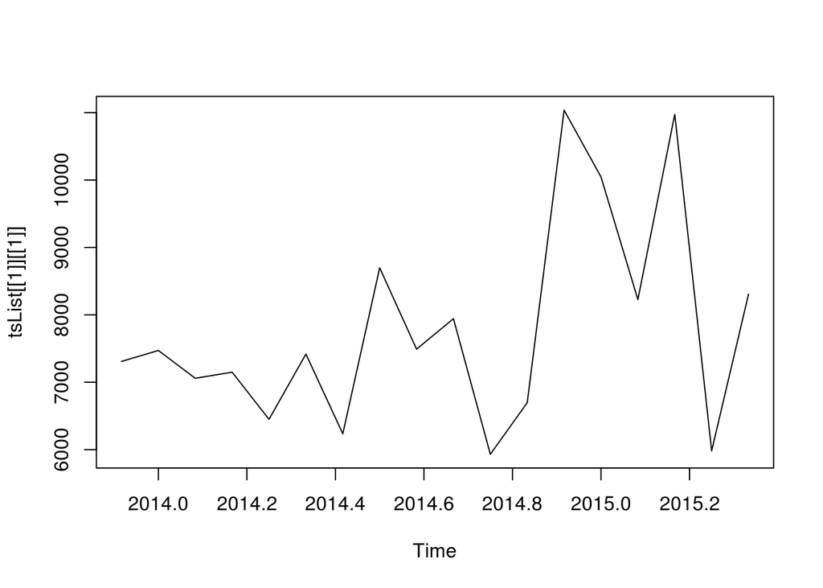

### Calculate growth rates

Growth rate = (x(tn) - x(tn-1))x(tn-1) Average growth rates are calculated from trimmed means of at least 3 values Outliers are trimmed by Hampel’s test (>3 SD from median)

View histograms of growth rates #### Monthly growth View monthly growth of first store

```
##              Jan         Feb         Mar         Apr         May
## 2014  0.02306509 -0.05770568  0.01402898 -0.09423182  0.15515878
## 2015 -0.12034779 -0.16579879  0.45945612 -0.60112392
##              Jun         Jul         Aug         Sep         Oct
## 2014 -0.13589009  0.32861337 -0.15191250  0.07617741 -0.30032212
## 2015
##              Nov         Dec
## 2014  0.06928212  0.43201147
## 2015
```

```
##      Min.   1st Qu.    Median      Mean   3rd Qu.      Max.      NA's
## -2.558000 -0.000649  0.020050  0.024670  0.050300  0.814100        25
```

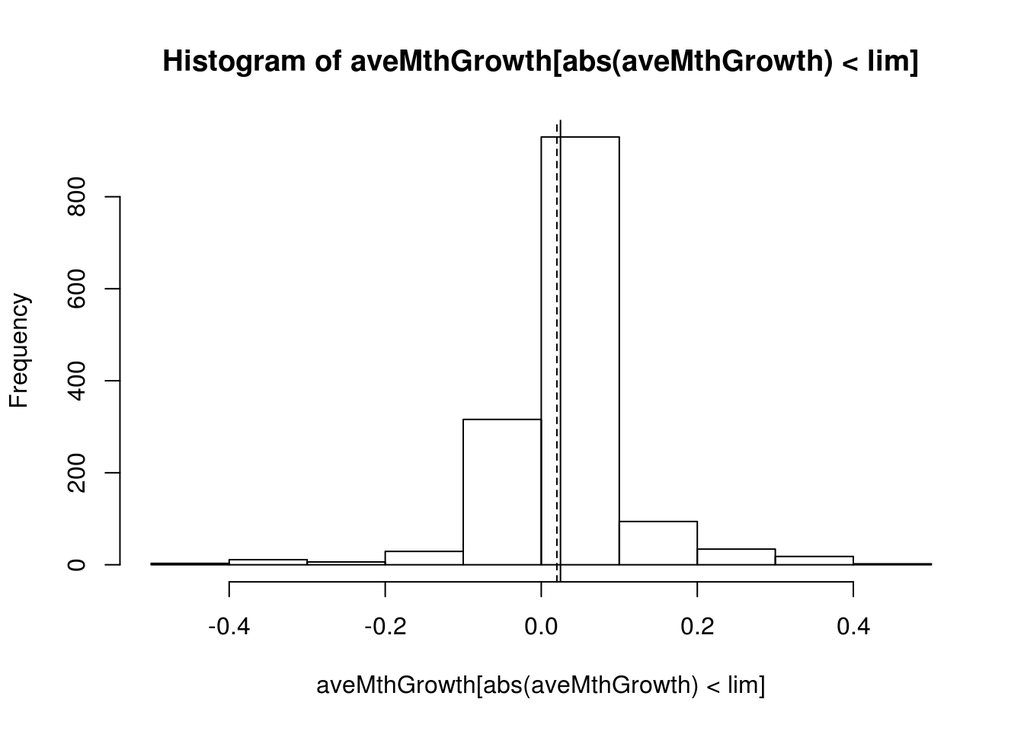

#### Quarterly growth

View quarterly growth of first store

```
##          as.xts(x[[1]]).Close
## Jan 2014                   NA
## Apr 2014           -0.1366635
## Jul 2014            0.3483990
## Oct 2014           -0.3179994
## Jan 2015            0.6936854
## Apr 2015           -0.4045837
```

```
##     Min.  1st Qu.   Median     Mean  3rd Qu.     Max.     NA's
## -0.92070 -0.01168  0.04852  0.06065  0.12220  0.99270      144
```

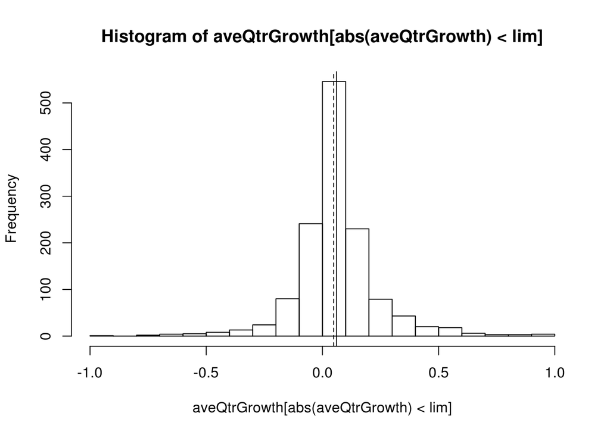

```
##          as.xts(x[[1]]).Close
## Jan 2014                   NA
## Jan 2015             0.344671
```

```
##     Min.  1st Qu.   Median     Mean  3rd Qu.     Max.     NA's
## -1.35000 -0.08698  0.12310  0.23190  0.38780  3.93500      176
```

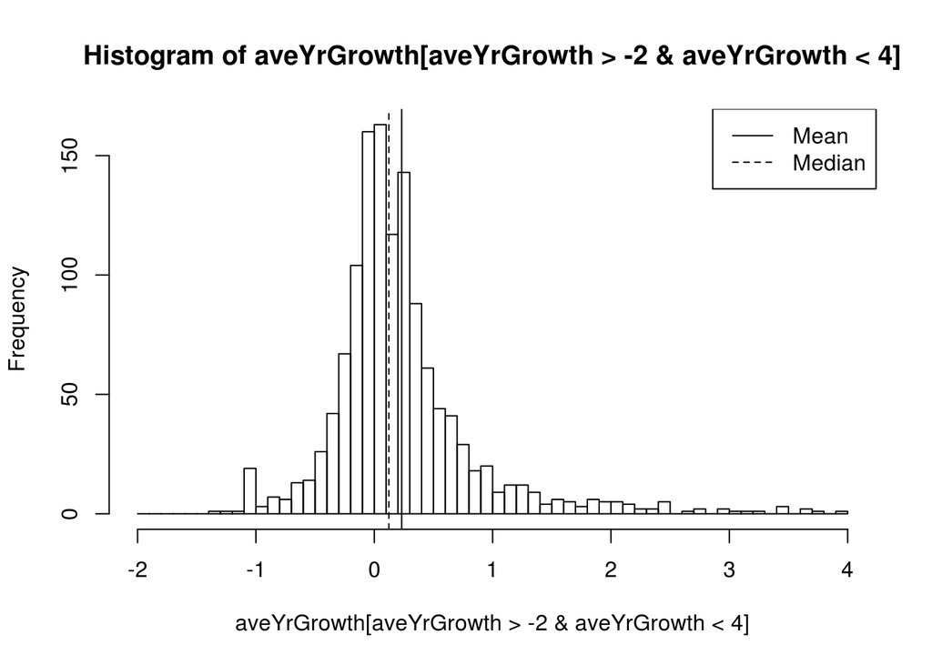

### Check for problematic stores

Some problemantic stores: 983030 182941, 979649, 086800, 015305 (not enough values, extreme growth rates, etc)

```r
tsList[["015305"]]
```

```
## [[1]]
##          Jan     Feb     Mar     Apr     May     Jun     Jul     Aug
## 2013
## 2014 -247.18   80.00  198.63   70.05  503.20 1466.83 -210.09 1170.09
## 2015 5229.85 1404.55  408.21  231.29    0.00
##          Sep     Oct     Nov     Dec
## 2013                          247.18
## 2014  696.19 5288.53 3686.49 2958.25
## 2015
```

```r
growth_yr[["015305"]]
```

```
##          as.xts(x[[1]]).Close
## Jan 2014                   NA
## Jan 2015             22.15806
```

```r
aveYrGrowth["015305"]
```

```
##   015305
## 22.15806
```

### Set thresholds for high growth

Min 5% average monthly growth, 10% quarterly growth, 25% yearly growth

```r
sum(na.omit(aveMthGrowth>0.05 & is.finite(aveMthGrowth)))   #368
```

```
## [1] 368
```

```r
sum(na.omit(aveQtrGrowth>0.1 & is.finite(aveQtrGrowth)))  #417
```

```
## [1] 417
```

```r
sum(na.omit(aveYrGrowth>0.25 & is.finite(aveYrGrowth)))     #499
```

```
## [1] 499
```

### Save growth rates and average growth rates into data frames

Dataframe of average growth rate

```r
aveGrowthDf=as.data.frame(cbind(aveMthGrowth,aveQtrGrowth,aveYrGrowth))
head(aveGrowthDf,3)
```

```
##        aveMthGrowth aveQtrGrowth aveYrGrowth
## 000026   0.03543897   0.03656756  0.34467099
## 000417  -0.02744613   0.02414632  0.09881195
## 001172   0.01740144   0.12220079  0.52929750
```

Indicator dataframe of high average growth rate using the above thresholds Min 5% average monthly growth, 10% quarterly growth, 25% yearly growth

```
##        highMthGrowth highQtrGrowth highYrGrowth
## 000026             0             0            1
## 000417             0             0            0
## 001172             0             1            1
```

Check for NA values

```r
sum(is.na(highGrowthDf))
```

```
## [1] 345
```

Check pairwise concordance among average monthly, quarterly and yearly growth rates

```
##              highQtrGrowth
## highMthGrowth   0   1
##             0 787 263
##             1 139 154
##              highYrGrowth
## highMthGrowth   0   1
##             0 682 355
##             1 126 144
##              highYrGrowth
## highQtrGrowth   0   1
##             0 662 246
##             1 140 252
```

View store with highest average monthly growth

```r
bestStore=names(which.max(aveMthGrowth))
aveMthGrowth[bestStore]
```

```
##    956367
## 0.8141476
```

```r
growth_mth[[bestStore]]
```

```
##             Jan        Feb        Mar        Apr        May        Jun
## 2014 -2.9929018 -1.1262266       -Inf  2.2731976  5.7591512 -0.4198432
## 2015        NaN        NaN        NaN        NaN
##             Jul        Aug        Sep        Oct        Nov        Dec
## 2014  2.8393248 -0.6336685 28.5149718       -Inf       -Inf        NaN
## 2015
```

```r
tsList[[bestStore]]
```

```
## [[1]]
##           Jan      Feb      Mar      Apr      May      Jun      Jul
## 2013
## 2014   337.65 -1329.92 -1480.67     0.00   651.36   113.10  1282.05
## 2015     0.00     0.00     0.00     0.00     0.00
##           Aug      Sep      Oct      Nov      Dec
## 2013                                      4317.97
## 2014   411.70  1373.51    33.73     0.00     0.00
## 2015
```

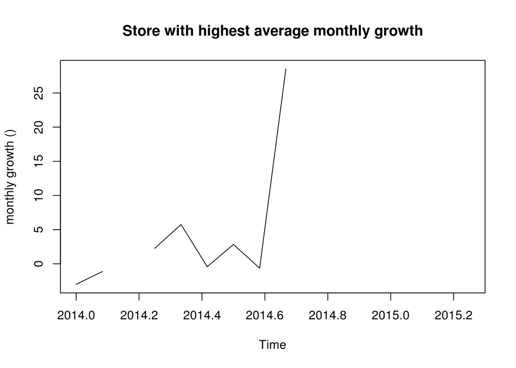

```r
#png("bestQtrGrowth.png")
plot(growth_mth[[bestStore]], main="Store with highest average monthly growth", ylab="monthly growth ()")
```

```r
#dev.off()
```

Save time series objects and data frames into data/revGrowth.RData

```r
save(tsList,highGrowthDf,aveGrowthDf,
     growth_mth,growth_qtr,growth_yr,file="revGrowth.RData")
```